# DE analysis, F vs M embryos, Zhu scWGBS data

pseudo-bulk analysis

```r
library("tidyverse")
library("ComplexHeatmap")
library("CTexploreR")
library("circlize")
library("SummarizedExperiment")
library("SingleCellExperiment")
library("DESeq2")
library("org.Hs.eg.db")
library("DropletUtils")
library("scater")
library("scran")
library("scuttle")
```

```r
load("~/cluster/Packages/CTdata/eh_data/all_genes.rda")

CT_genes_X_met <- all_genes %>%
  filter(CT_gene_type == "CT_gene") %>%
  filter(X_linked, regulated_by_methylation) %>%
  pull(external_gene_name)
```

Data from: [Single-cell DNA methylome sequencing of human preimplantation embryos. Nat Genet 50, 12–19 (2018). Zhu, P., Guo, H., Ren, Y. et al.](https://doi.org/10.1038/s41588-017-0007-6)

**Started from raw files**

- Downloaded all fastq files (including scRNAseq fastq files from ICM and TE cells)

see `/storage/research/dduv/cbio-lg/cluster/DataSets/early_embryos/Zhu_dataset/scRNAseq_reprocessed_data/` folder

- All files were reprocessed, in order to:

– Show expression values in TPM rather than FPKM (previous data was downloaded on GEO as an count matrix of already processed data in FPKM values)

– Use all the cells for the differential expression analysis instead of using only the few available “bulk samples”

– Test in parallel the expression of CG X-linked MethDep when multimapping was allowed

# Pre-processing

## Quality control

```r
load("/storage/research/dduv/cbio-lg/cluster/DataSets/early_embryos/Zhu_dataset/scRNAseq_reprocessed_data/processed_data/count_matrix/coldata.rda")
load("/storage/research/dduv/cbio-lg/cluster/DataSets/early_embryos/Zhu_dataset/scRNAseq_reprocessed_data/processed_data/count_matrix/raw_counts.rda")

coldata <- as.data.frame(coldata)
rownames(coldata) <- coldata$sample
coldata$gender <- ifelse(coldata$gender == "male", "M", "F")

sce <- SingleCellExperiment(assays = counts[, coldata$sample],
                      colData = coldata)

# No mitochondrial genes (not in GTF or in genome ref used for alignment?)
# grep("^MT-", x = mapIds(org.Hs.eg.db, rownames(sce), "SYMBOL", "ENSEMBL"), value = TRUE)

sce <- sce[rowSums(assay(sce)) > 0,]

sce$gender <- factor(sce$gender, levels = c("M", "F"))

rowData(sce)$gene <- mapIds(org.Hs.eg.db, rownames(sce), "SYMBOL", "ENSEMBL")

assayNames(sce) <- "counts"
rowData(sce)$is_mito <- FALSE
rowData(sce)$is_mito[grep(pattern = "^MT-", x = rowData(sce)$gene, value = FALSE)] <- TRUE
sce <- addPerCellQC(sce, subsets=list(Mito = rowData(sce)$is_mito))
# No MT genes
#table(sce$subsets_Mito_percent)

table(sce$cell_type, sce$gender)
```

```
##
##        M  F
##   ICM 21 29
##   TE  21 28
```

### Number of detected genes

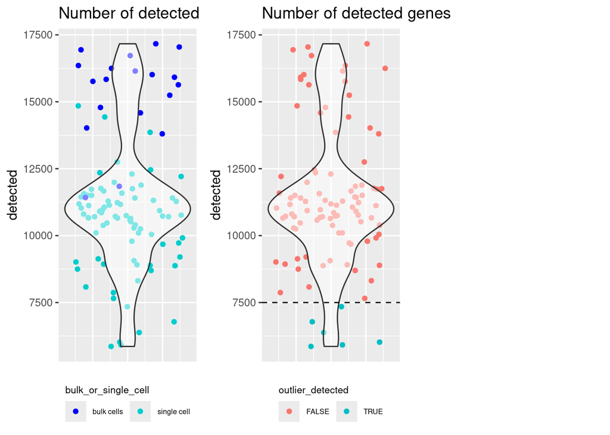

```r
thr_detection <- 7500

# Define outliers with low detection level
outliers <- colnames(sce)[isOutlier(sce$detected, type = "lower")]
outliers <- colnames(sce)[sce$detected < thr_detection]
##outliers

sce$outlier_detected <- FALSE
sce$outlier_detected[sce$sample %in% outliers] <- TRUE

f1 <- as_tibble(colData(sce)) %>%
  ggplot(aes(x = 1, y = detected)) +
  geom_jitter(aes(x = 1, y = detected, color = outlier_detected)) +
  geom_violin(alpha = 0.5, outliers = F) +
  geom_hline(yintercept = thr_detection, linetype = "dashed") +
  theme(legend.position = "bottom",
        legend.title.position =  "top",
        legend.title = element_text(size = 8),
        legend.text = element_text(size = 6),
                axis.title.x = element_blank(),
        axis.text.x = element_blank(),
        axis.ticks.x = element_blank()) +
  ggtitle("Number of detected genes")


f2 <- as_tibble(colData(sce)) %>%
  ggplot(aes(x = 1, y = detected)) +
  geom_jitter(aes(x = 1, y = detected, color = bulk_or_single_cell)) +
  geom_violin(alpha = 0.5, outliers = F) +
    scale_color_manual(values = c("blue", "cyan3"))+
  theme(legend.position = "bottom",
        legend.title.position =  "top",
        legend.title = element_text(size = 8),
        legend.text = element_text(size = 6),
                axis.title.x = element_blank(),
        axis.text.x = element_blank(),
        axis.ticks.x = element_blank())+
  ggtitle("Number of detected genes")

gridExtra::grid.arrange(f2, f1, ncol = 3)
```

cells with less than 7500 are considered as outliers

### Sequencing depth

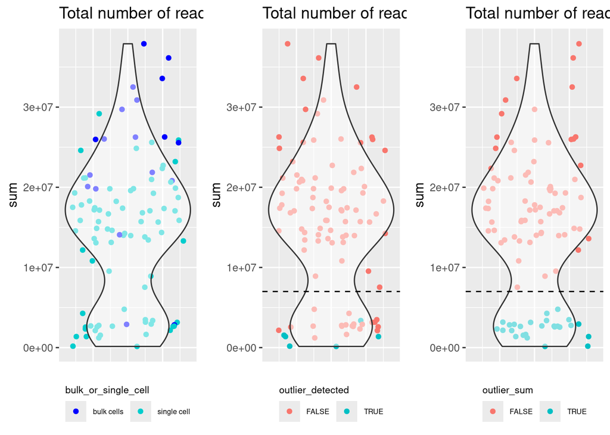

```r
thr_sum <- 7000000
outliers <- colnames(sce)[sce$sum < thr_sum]

sce$outlier_sum <- FALSE
sce$outlier_sum[sce$sample %in% outliers] <- TRUE

f1 <- as_tibble(colData(sce)) %>%
  ggplot(aes(x = 1, y = sum)) +
  geom_jitter(aes(x = 1, y = sum, color = outlier_sum)) +
  geom_violin(alpha = 0.5, outliers = F) +
  geom_hline(yintercept = thr_sum, linetype = "dashed") +
  theme(legend.position = "bottom",
        legend.title.position =  "top",
        legend.title = element_text(size = 8),
        legend.text = element_text(size = 6),
                axis.title.x = element_blank(),
        axis.text.x = element_blank(),
        axis.ticks.x = element_blank()) +
  ggtitle("Total number of reads")

f3 <- as_tibble(colData(sce)) %>%
  ggplot(aes(x = 1, y = sum)) +
  geom_jitter(aes(x = 1, y = sum, color = outlier_detected)) +
  geom_violin(alpha = 0.5, outliers = F) +
  geom_hline(yintercept = thr_sum, linetype = "dashed") +
  theme(legend.position = "bottom",
        legend.title.position =  "top",
        legend.title = element_text(size = 8),
        legend.text = element_text(size = 6),
                axis.title.x = element_blank(),
        axis.text.x = element_blank(),
        axis.ticks.x = element_blank()) +
  ggtitle("Total number of reads")

f2 <- as_tibble(colData(sce)) %>%
  ggplot(aes(x = 1, y = sum)) +
  geom_jitter(aes(x = 1, y = sum, color = bulk_or_single_cell)) +
  geom_violin(alpha = 0.5, outliers = F) +
  scale_color_manual(values = c("blue", "cyan3"))+
  theme(legend.position = "bottom",
        legend.title.position =  "top",
        legend.title = element_text(size = 8),
        legend.text = element_text(size = 6),
                axis.title.x = element_blank(),
        axis.text.x = element_blank(),
        axis.ticks.x = element_blank())+
  ggtitle("Total number of reads")

gridExtra::grid.arrange(f2, f3, f1, ncol = 3)
```

### Ouliers identification

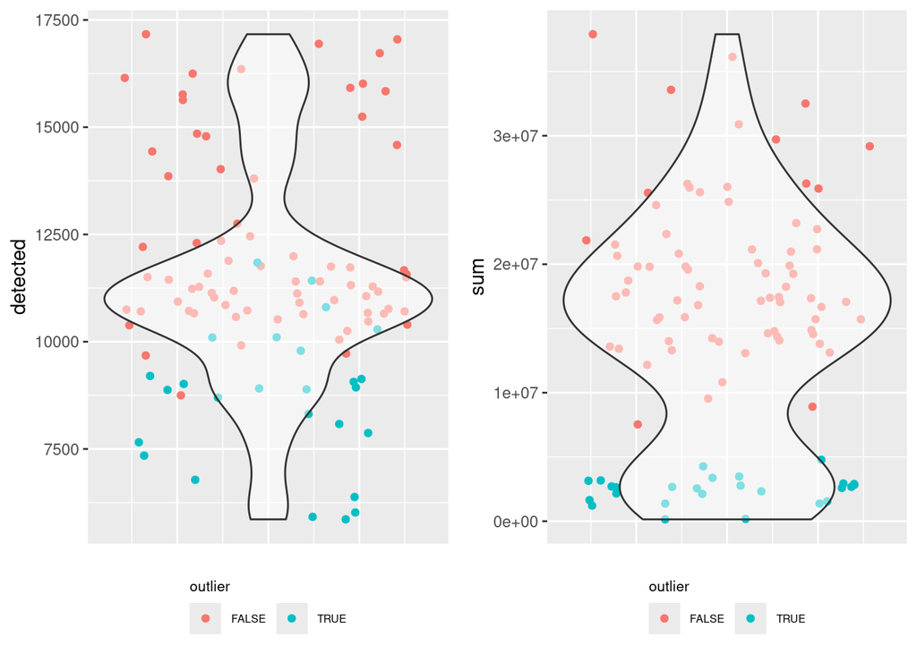

```r
outliers <- as_tibble(colData(sce)) %>%
  filter(outlier_sum | outlier_detected) %>%
  pull(sample)

sce$outlier <- FALSE
sce$outlier[sce$sample %in% outliers] <- TRUE

# Define outliers with low sum value
f1 <- as_tibble(colData(sce)) %>%
  ggplot(aes(x = 1, y = detected)) +
  geom_jitter(aes(x = 1, y = detected, color = outlier)) +
  geom_violin(alpha = 0.5, outliers = F) +
  theme(legend.position = "bottom",
        legend.title.position =  "top",
        legend.title = element_text(size = 8),
        legend.text = element_text(size = 6),
        axis.title.x = element_blank(),
        axis.text.x = element_blank(),
        axis.ticks.x = element_blank())

f2 <- as_tibble(colData(sce)) %>%
  ggplot(aes(x = 1, y = sum)) +
  geom_jitter(aes(x = 1, y = sum, color = outlier)) +
  geom_violin(alpha = 0.5, outliers = F) +
  theme(legend.position = "bottom",
        legend.title.position =  "top",
        legend.title = element_text(size = 8),
        legend.text = element_text(size = 6),
        axis.title.x = element_blank(),
        axis.text.x = element_blank(),
        axis.ticks.x = element_blank())

gridExtra::grid.arrange(f1, f2, ncol = 2)
```

=> Removed outlier cells

```r
table(outlier =sce$outlier)
```

```
## outlier
## FALSE  TRUE
##    73    26
```

```r
sce <- sce[, !sce$outlier]
```

=> 73 cells kept

```r
table(sce$cell_type, sce$gender)
```

```
##
##        M  F
##   ICM 15 24
##   TE  15 19
```

### No link between data’s quality and sex factor

Checked that the data’s quality is independant of sex factor:

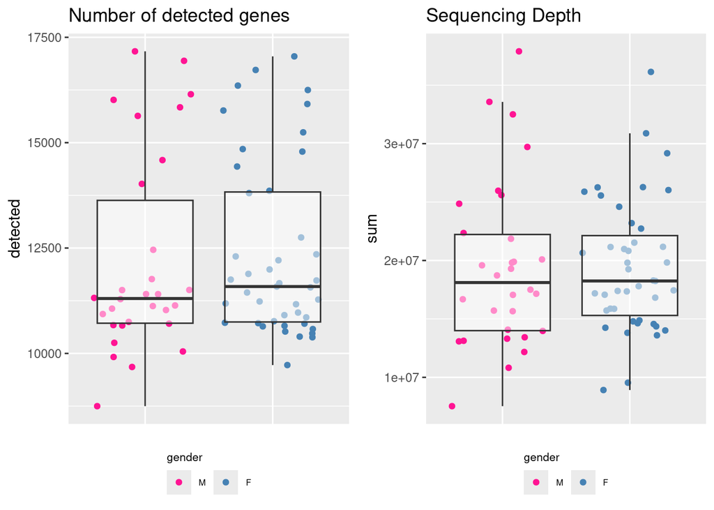

```r
a <- as_tibble(colData(sce)) %>%
  ggplot(aes(x = gender, y = detected)) +
  geom_jitter(aes(x = gender, y = detected, color = gender)) +
  geom_boxplot(alpha = 0.5, outliers = F) +
    scale_color_manual(values = c("deeppink", "steelblue"))+
  theme(legend.position = "bottom",
        legend.title.position =  "top",
        legend.title = element_text(size = 8),
        legend.text = element_text(size = 6),
        axis.title.x = element_blank(),
        axis.text.x = element_blank(),
        axis.ticks.x = element_blank())+
  ggtitle("Number of detected genes")


b <- as_tibble(colData(sce)) %>%
  ggplot(aes(x = gender, y = sum)) +
  geom_jitter(aes(x = gender, y = sum, color = gender)) +
  geom_boxplot(alpha = 0.5, outliers = F) +
    scale_color_manual(values = c("deeppink", "steelblue"))+
  theme(legend.position = "bottom",
        legend.title.position =  "top",
        legend.title = element_text(size = 8),
        legend.text = element_text(size = 6),
        axis.title.x = element_blank(),
        axis.text.x = element_blank(),
        axis.ticks.x = element_blank())+
  ggtitle("Sequencing Depth")


gridExtra::grid.arrange(a,b, ncol = 2)
```

### Normalisation

```r
## Normalisation
sce <- logNormCounts(sce, transform = "none")
sce <- logNormCounts(sce)

# Normalise into TPMs for visualisations
featureC_results <- read_tsv("/storage/research/dduv/cbio-lg/cluster/DataSets/early_embryos/Zhu_dataset/scRNAseq_reprocessed_data/processed_data/featurecounts/SRR6010592_featurecounts.tsv",
                             skip = 1, col_names = TRUE)


# Check the order of the genes
#unique(rownames(counts) == featureC_results$Geneid)
x1 <- counts / featureC_results$Length * 1000
total <- colSums(x1)

TPM_matrix <- as_tibble(x1, rownames = "ensembl_gene_id") %>%
  gather(sample, counts, -ensembl_gene_id) %>%
  left_join(enframe(total) %>%
              dplyr::rename(sample = name, total = value)) %>%
  mutate(TPM = counts / total * 1000000) %>%
  dplyr::select(ensembl_gene_id, sample, TPM) %>%
  spread(sample, TPM)
TPM <- as.matrix(TPM_matrix[,-1])
rownames(TPM) <- TPM_matrix$ensembl_gene_id

assay(sce, "TPM") <- TPM[rownames(sce), colnames(sce)]
```

# CG genes Heatmaps

```r
my_genes <- all_genes %>%
  filter(CT_gene_type == "CT_gene") %>%
  filter(X_linked, regulated_by_methylation) %>%
  filter(ensembl_gene_id %in% rownames(sce))

legend_colors <- c(
  "#5E4FA2", "#3288BD", "#66C2A5", "#ABDDA4", "#E6F598",
  "#FFFFBF", "#FEE08B", "#FDAE61", "#F46D43", "#D53E4F",
  "#9E0142")

legends_param <- list(
  labels_gp = gpar(col = "black", fontsize = 7),
  title_gp = gpar(col = "black", fontsize = 7, fontface = "bold"),
  simple_anno_size = unit(0.1, "cm"),
  row_names_gp = gpar(fontsize = 7),
  annotation_name_side = "left",
  border = FALSE,
  border_gp = gpar(lwd = 0.1),
  grid_width = unit(0.2, "cm"),
  grid_height = unit(0.2, "cm"),
  legend_height = unit(0.2, "cm"))

draw_embryo_exp_Zhu_dataset <- function(genes,
                            rm_outlier = FALSE,
                            cell_type = NULL,
                            detected_in_percent_of_cells = 0,
                            split_rows_by = "chr_met",
                            font_size = 6,
                            gender = NULL,
                            logTransform = FALSE,
                            assayName = "TPM",
                            scale_lims = NULL,
                            clustRow = TRUE,
                            h_width = 8,
                            h_height = 8,
                            show_right_annot = TRUE,
                            clust_method = "centroid"){



  # Top Annotations
  df_col <- colData(sce)

  if(rm_outlier) df_col <- df_col[!df_col$outlier,]
  fig_title <- "Blastocyst cells"
  if(!is.null(cell_type)) {
    df_col <- df_col[df_col$cell_type == cell_type,]
    fig_title <- paste0(cell_type, " cells")
  }

  df_col$sex <- df_col$gender
  levels(df_col$sex) <- c("Male", "Female")
  df_col <- df_col[order(df_col$sex, df_col$cell_type ),]
  df_col$Stage <- df_col$cell_type
  df_col$bulk_or_single_cell <- df_col$bulk_or_single_cell
  df_col$group <- paste0(df_col$sex, " ", df_col$cell_type, " cells")


  column_ha_sex = HeatmapAnnotation(
    sex = df_col$sex,
    col = list(sex = c("Female" = "deeppink", "Male" = "steelblue")),
        border = FALSE,
    simple_anno_size = unit(0.2, "cm"),
    annotation_legend_param = legends_param,
    annotation_name_gp = gpar(fontsize = 0))

    column_ha_Stage = HeatmapAnnotation(
    CellType = df_col$Stage,
    col = list(CellType = c("ICM" = "gray", "TE" = "gray10")),
    border = FALSE,
    simple_anno_size = unit(0.2, "cm"),
    annotation_legend_param = legends_param,
    annotation_name_gp = gpar(fontsize = 0))

  column_ha_bulk = HeatmapAnnotation(
    bulk_or_single_cell = df_col$bulk_or_single_cell,
    col = list(bulk_or_single_cell = c("single cell" = "cyan3", "bulk cells" = "blue")),
    border = FALSE,
    simple_anno_size = unit(0.2, "cm"),
    annotation_legend_param = legends_param,
    annotation_name_gp = gpar(fontsize = 0))

  column_ha_outlier = HeatmapAnnotation(
    outlier = df_col$outlier,
    col = list(outlier = c("TRUE" = "cyan", "FALSE" = "gray10")),
    border = FALSE,
    simple_anno_size = unit(0.2, "cm"),
    annotation_legend_param = legends_param,
    annotation_name_gp = gpar(fontsize = 0))


  column_ha_sample = HeatmapAnnotation(
    sample = df_col$source_name,
    #col = list(outlier = c("TRUE" = "cyan", "FALSE" = "gray10")),
    border = FALSE,
    simple_anno_size = unit(0.2, "cm"),
    annotation_legend_param = legends_param,
    annotation_name_gp = gpar(fontsize = 0))

  column_ha_detected = HeatmapAnnotation(
    detected = df_col$detected,
    #col = list(outlier = c("TRUE" = "cyan", "FALSE" = "gray10")),
    border = FALSE,
    simple_anno_size = unit(0.2, "cm"),
    annotation_legend_param = legends_param,
    annotation_name_gp = gpar(fontsize = 0))

  ensembl_gene <- data.frame(external_gene_name = all_genes$external_gene_name)
  rownames(ensembl_gene) <- all_genes$ensembl_gene_id

  genes <- genes[genes %in% rownames(sce)]

  mat <- assay(sce, assayName)[genes, ]
  rownames(mat) <- ensembl_gene[rownames(mat),]

  # Show only genes detected in more than x% of cells
  mat <- mat[rowSums(mat > 0) >= dim(mat)[2]*detected_in_percent_of_cells,]

  if (logTransform) mat <- log1p(mat)

   if (is.null(scale_lims)) scale_lims <- c(0, max(mat))
  heatmap_colors <- colorRamp2(
    seq(scale_lims[1], scale_lims[2], length = 11), legend_colors)

  lines <- tibble(gene = rownames(mat)) %>%
    mutate(group = case_when(gene %in% CT_genes$external_gene_name ~ "X-linked CG MethDep",
                             !gene %in% CT_genes$external_gene_name ~ "Control")) %>%
    mutate(group = factor(group, levels = c("X-linked CG MethDep", "Control")))



  ht1 <- Heatmap(mat[, rownames(df_col)],
                 name = assayName,
                 #column_title = fig_title,
                 clustering_method_rows = "ward.D2",
                 clustering_method_columns = "ward.D2",
                 column_split = df_col$sex,
                 row_split = lines$group,
                 row_gap = unit(c(1), "mm"),
                 col = heatmap_colors,
                 cluster_rows = clustRow,
                 cluster_columns = FALSE,
                 cluster_row_slices = FALSE,
                 cluster_column_slices = FALSE,
                 show_row_names = TRUE,
                 show_column_names = FALSE,
                 show_row_dend = FALSE,
                 column_names_gp = gpar(fontsize = 8),
                 column_names_centered = TRUE,
                 row_names_gp = gpar(fontsize = font_size),
                 row_names_side = "left",
                 border = TRUE,
                 border_gp = gpar(lwd = 0.5),
                 column_names_side = c("bottom"),
                 column_names_rot = 90,
                 column_title_gp = gpar(fontsize = 10, face = "bold"),
                 row_title_gp = gpar(fontsize = 0),
                 top_annotation = c(column_ha_Stage,
                                     column_ha_sex,
                 #                    # column_ha_sample,
                                     gap = unit(0.1, "mm")),
                 # use_raster = TRUE,
                 # raster_device = "CairoPNG",
                 # raster_quality = 10,
                 width = unit(h_width, "cm"),
                 height = unit(h_height, "cm"),
                 heatmap_legend_param = legends_param)

  ht1
}

controls <- all_genes %>%
  filter(external_gene_name %in% c("DDX3Y", "RPS4Y1", "EIF1AY"))

fig <- draw_embryo_exp_Zhu_dataset(genes = c(my_genes$ensembl_gene_id, controls$ensembl_gene_id),
                            clustRow = T,
                            cell_type = NULL,
                            font_size = 5,
                            scale_lims = c(0, 100),
                            h_width = 5,
                            h_height = 4,
                            logTransform = F,
                            detected_in_percent_of_cells = 0.2)



pdf(file = "../figs/Fig8B_Heatmap_CG_metDep_in_Zhu_dataset.pdf", width = 6, height = 4)
fig

dev.off()
```

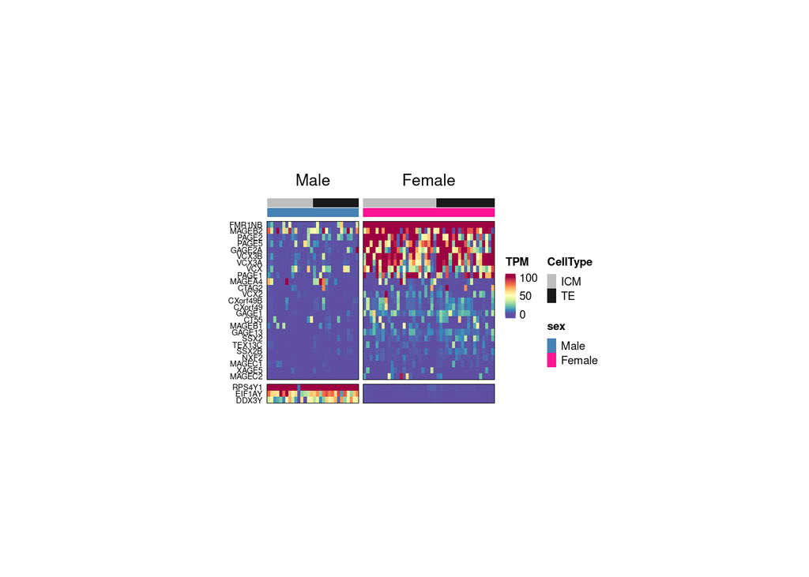

```r
fig
```

NB: Are represented on the heatmap only genes detected in more than 20% of cells

# Differential expression analysis

**pseudo-bulk samples**

Group cells by embryo

Kept embryos with more than one cell

```r
dds_pb <- scuttle::summarizeAssayByGroup(sce,
                            ids = colData(sce)[, "source_name"],
                            statistics = "sum")

coldata <- tibble(source_name = dds_pb$ids,
                  ncells = dds_pb$ncells) %>%
  left_join(as_tibble(colData(sce)) %>%
              dplyr::select(source_name, cell_type, gender) %>%
              unique()) %>%
  as.data.frame()

rownames(coldata) <- coldata$source_name

dds_pb$cell_type <- coldata[colnames(dds_pb),]$cell_type
dds_pb$gender <- coldata[colnames(dds_pb),]$gender
dds_pb$sample <- coldata[colnames(dds_pb),]$source_name
dds_pb$embryo <- paste0("embryo", gsub("Te", '', gsub("Icm", '', x = gsub("-\\w*", '', x = dds_pb$sample))))

dds_pb <- dds_pb[, dds_pb$ncells > 1]

as_tibble(colData(dds_pb)) %>%
  DT::datatable()
```

|  | ids | ncells | cell_type | gender | sample | embryo |
| --- | --- | --- | --- | --- | --- | --- |
| 1 | Icm01-W | 8 | ICM | M | Icm01-W | embryo01 |
| 2 | Icm02-W | 8 | ICM | F | Icm02-W | embryo02 |
| 3 | Icm03-W | 7 | ICM | F | Icm03-W | embryo03 |
| 4 | Icm04-W | 8 | ICM | F | Icm04-W | embryo04 |
| 5 | Icm05-W | 6 | ICM | M | Icm05-W | embryo05 |
| 6 | Te01-W | 4 | TE | M | Te01-W | embryo01 |
| 7 | Te02-W | 10 | TE | F | Te02-W | embryo02 |
| 8 | Te03-W | 7 | TE | F | Te03-W | embryo03 |
| 9 | Te04-W | 2 | TE | F | Te04-W | embryo04 |
| 10 | Te05-W | 10 | TE | M | Te05-W | embryo05 |

```r
dds <- DESeqDataSetFromMatrix(countData = assay(dds_pb),
                              colData = colData(dds_pb),
                              design = ~ cell_type + gender)

dds$gender <- factor(dds$gender, levels = c("M", "F"))

dds <- estimateSizeFactors(dds)
filtering_thr <- 10
keep <- rowSums(counts(dds, normalize = TRUE) >= filtering_thr ) >= 3
dds <- DESeq(dds[keep,])

table(dds$cell_type, dds$gender)
```

```
##
##       M F
##   ICM 2 3
##   TE  2 3
```

## PCA

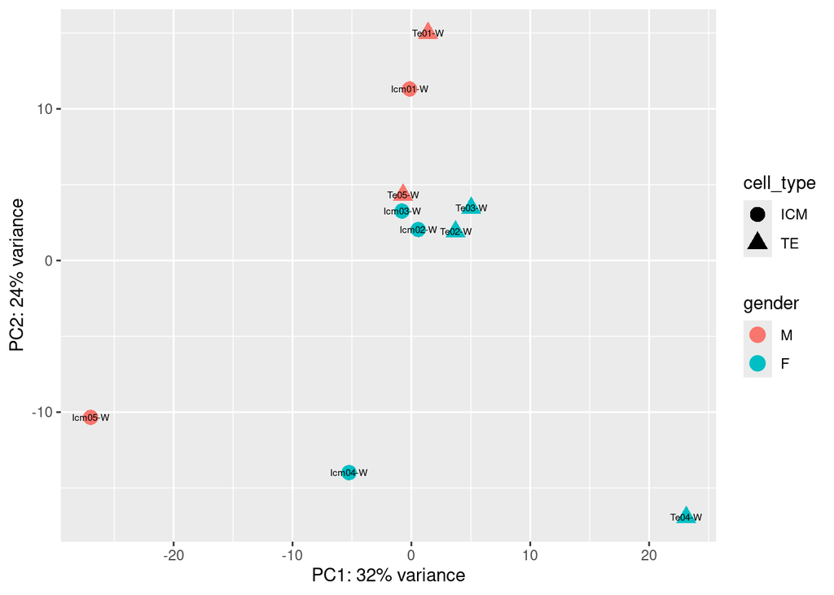

```r
## PCA
rld <- varianceStabilizingTransformation(dds)
rv <- rowVars(assay(rld))
selected <- order(rv, decreasing = TRUE)[seq_len(min(500, length(rv)))]
pca <- prcomp(t(assay(rld)[selected, ]))
percentVar <- pca$sdev^2/sum(pca$sdev^2)
percentVar_1 <- paste0("PC1: ", round(percentVar[1] * 100), "% variance")
percentVar_2 <- paste0("PC2: ", round(percentVar[2] * 100), "% variance")
percentVar_3 <- paste0("PC3: ", round(percentVar[3] * 100), "% variance")
percentVar_4 <- paste0("PC4: ", round(percentVar[4] * 100), "% variance")
pcaData <- as_tibble(pca$x, rownames = "samples") %>%
  dplyr::select(samples, "PC1", "PC2", "PC3", "PC4") %>%
  left_join(as_tibble(colData(dds), rownames = "samples"))

ggplot(pcaData, aes(x = PC1, y = PC2, col = gender, shape = cell_type, label = sample)) +
  geom_point(size = 4) +
  xlab(percentVar_1) +
  ylab(percentVar_2) +
  geom_text(color = "black", size = 2)
```

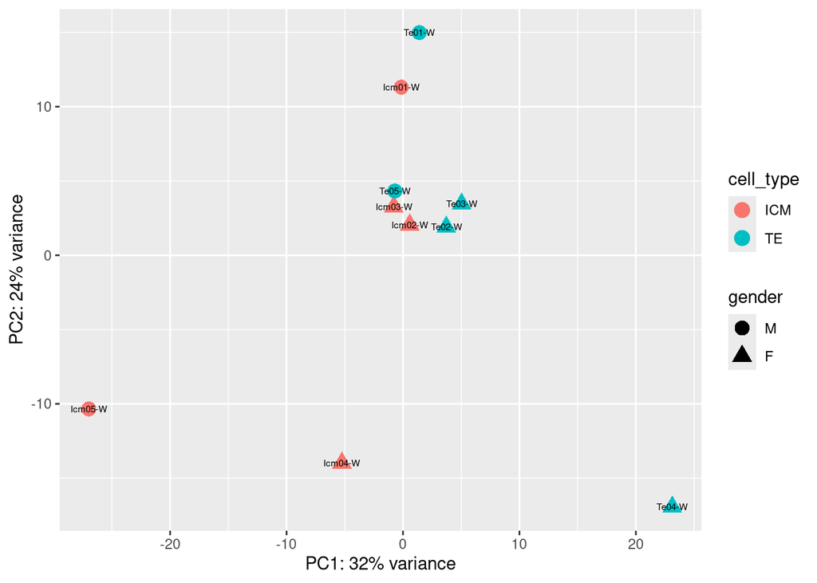

```r
ggplot(pcaData, aes(x = PC1, y = PC2, col = cell_type, shape = gender, label = sample)) +
  geom_point(size = 4) +
  xlab(percentVar_1) +
  ylab(percentVar_2) +
  geom_text(color = "black", size = 2)
```

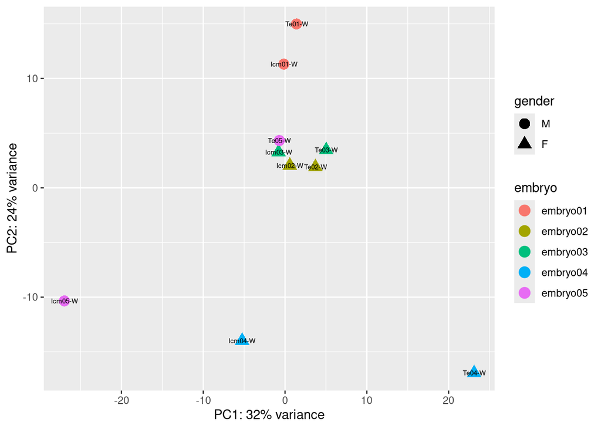

```r
ggplot(pcaData, aes(x = PC1, y = PC2, col = embryo, shape = gender, label = sample)) +
  geom_point(size = 4) +
  xlab(percentVar_1) +
  ylab(percentVar_2) +
  geom_text(color = "black", size = 2)
```

## Volcano plot

```r
resultsNames(dds)
```

```
## [1] "Intercept"           "cell_type_TE_vs_ICM" "gender_F_vs_M"
```

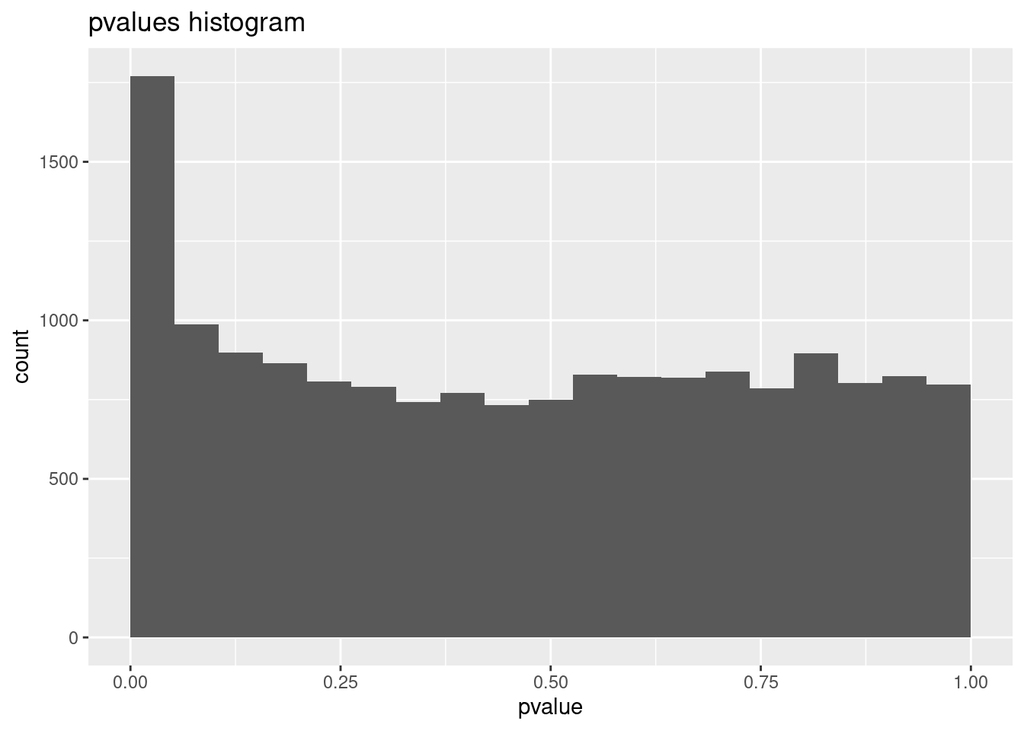

```r
res_dds <- results(dds,
                   name = "gender_F_vs_M",
                   independentFiltering = FALSE)

#load("~/cluster/CBIO-templates/ensembl_2_geneName/transcripts_infos.rda")

res_tbl <- as_tibble(res_dds, rownames = "ensembl_gene_id") %>%
  left_join(all_genes %>% dplyr::select(ensembl_gene_id, external_gene_name, chr) %>% unique()) %>%
  arrange(padj)

padj_thr <- 0.05
log2FC_thr <- 1

ggplot(res_tbl %>% filter(!is.na(padj)), aes(x = pvalue)) +
    geom_histogram(bins = 20, boundary = 0) +
  ggtitle("pvalues histogram")
```

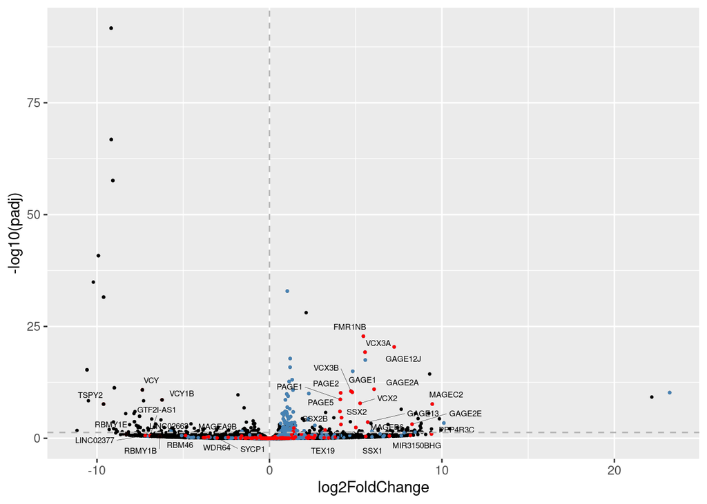

```r
res_tbl %>%
  filter(!is.na(padj)) %>%
  ggplot(aes(x= log2FoldChange, y = -log10(padj))) +
  geom_point(size = 0.5) +
    geom_point(data = res_tbl %>%
               filter(chr == "X"),
             aes(x= log2FoldChange, y = -log10(padj)),
             color = "steelblue", size = 0.55) +
  geom_point(data = res_tbl %>%
               filter(external_gene_name %in% CT_genes$external_gene_name),
             aes(x= log2FoldChange, y = -log10(padj)),
             color = "red", size = 0.55) +
  geom_point(data = res_tbl %>%
               filter(chr == "Y"),
             aes(x= log2FoldChange, y = -log10(padj)),
             color = "black", size = 0.55) +
  ylab("-log10(padj)") +
  ggrepel::geom_text_repel(data = subset(res_tbl, external_gene_name %in% CT_genes$external_gene_name),
                           aes(x = log2FoldChange, y = -log10(padj), label = external_gene_name),
                           size = 2,
                           segment.size = 0.1, max.overlaps = 30) +
  geom_vline(xintercept = 0, linetype = "dashed", color = "gray70") +
  geom_hline(yintercept = -log10(padj_thr), linetype = "dashed", color = "gray70")
```

### Volcano plot for paper

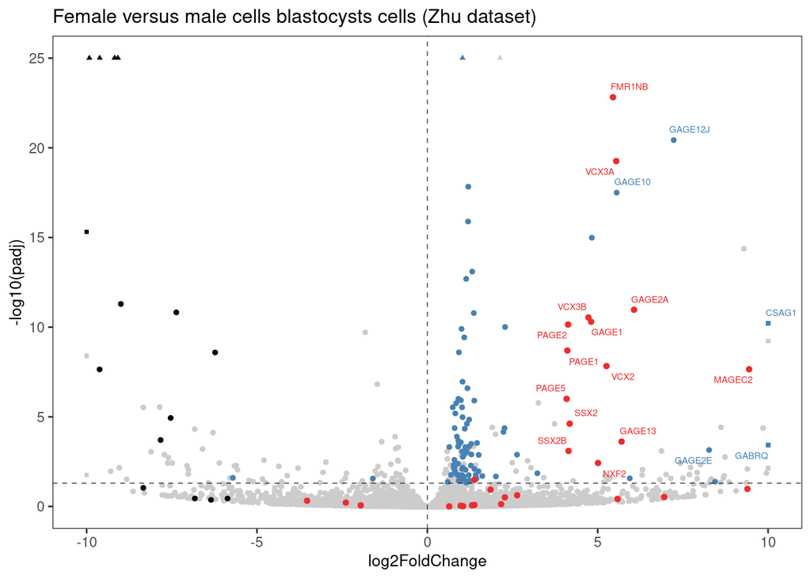

```r
load("~/cluster/Packages/CTdata/eh_data/CT_genes.rda")

CTP_genes <- CT_genes %>%
  filter(CT_gene_type == "CTP_gene")

CT_genes <- CT_genes %>%
  filter(CT_gene_type == "CT_gene")

thr <- 1e-25
logFC_thr <- 10
res_tbl_modified <- res_tbl %>%
  mutate(group = case_when(padj < thr ~ "padj_outlier",
                           abs(log2FoldChange) >= logFC_thr ~ "logFC_outlier",
                           padj > thr & abs(log2FoldChange) < logFC_thr ~ "others")) %>%
  mutate(padj = ifelse(padj <= thr, thr, padj)) %>%
  mutate(log2FoldChange = ifelse(log2FoldChange >= logFC_thr, logFC_thr, log2FoldChange)) %>%
   mutate(log2FoldChange = ifelse(log2FoldChange <= -logFC_thr, -logFC_thr, log2FoldChange)) %>%
  filter(chr %in% c(1:22, "X", "Y")) %>%
  mutate(chr = case_when(chr %in% c("X", "Y") ~ chr,
                         !chr %in% c("X", "Y") ~ "Autosome")) %>%
  mutate(X_CG_MethDEp = case_when(external_gene_name %in% CT_genes$external_gene_name ~ TRUE,
                             external_gene_name %in% CT_genes$external_gene_name ~ FALSE)) %>%
  filter(!is.na(padj)) %>%
  filter(!is.na(group))
  #filter(abs(log2FoldChange) > 0.05)

labeled_X_genes <- res_tbl_modified %>%
  filter(chr == "X") %>%
  filter(abs(log2FoldChange) > 5  & padj < 0.005) %>%
  filter(!external_gene_name %in% CT_genes$external_gene_name) %>%
  arrange(padj)

labeled_CT_genes <- res_tbl_modified %>%
  filter(external_gene_name %in% CT_genes_X_met & padj < 0.05 & log2FoldChange > 2) %>%
  arrange(padj)

X_sign_genes <- res_tbl_modified %>%
  filter(chr == "X") %>%
  filter(padj < padj_thr) %>%
  arrange(padj) #%>% head(30)

Y_sign_genes <- res_tbl_modified %>%
  filter(chr == "Y") %>%
  #filter(padj < padj_thr) %>%
  filter(log2FoldChange < 0 ) %>%
  arrange(padj) #%>% head(30)


set.seed = 123
fig <- res_tbl_modified %>%
  ggplot(aes(x= log2FoldChange, y = -log10(padj))) +
  geom_point(data = res_tbl_modified,
             aes(x= log2FoldChange, y = -log10(padj), shape = group),
             size = 1, color = "gray80") +
    geom_point(data = res_tbl_modified %>%
               filter(external_gene_name %in% X_sign_genes$external_gene_name),
             aes(x= log2FoldChange, y = -log10(padj), shape = group),
             size = 1, color = "steelblue") +
  geom_point(data = res_tbl_modified %>%
               filter(ensembl_gene_id %in% Y_sign_genes$ensembl_gene_id),
             aes(x= log2FoldChange, y = -log10(padj), shape = group),
             size = 1, color = "black") +
  geom_point(data = res_tbl_modified %>%
               filter(external_gene_name %in% CT_genes_X_met),# & padj < padj_thr),
             aes(x= log2FoldChange, y = -log10(padj), shape = group),
             size = 1.2, color = "firebrick2") +
  scale_shape_manual(values = c(15, 19, 17))+
  xlab("log2FoldChange") +
  ylab("-log10(padj)") +
  geom_vline(xintercept = 0, linetype = "dashed",
             color = "black", linewidth = 0.2) +
  # geom_vline(xintercept = -1, linetype = "dashed",
  #            color = "black", linewidth = 0.2) +
  geom_hline(yintercept = -log10(padj_thr),
             linetype = "dashed", color = "black", linewidth = 0.2) +
  ggrepel::geom_text_repel(data = subset(res_tbl_modified, external_gene_name %in% labeled_X_genes$external_gene_name),
                           aes(x = log2FoldChange, y = -log10(padj), label = external_gene_name),
                           size = 2, color = "steelblue",
                           segment.size = 0.1, max.overlaps = 10) +
   ggrepel::geom_text_repel(data = subset(res_tbl_modified, external_gene_name %in% labeled_CT_genes$external_gene_name),
                           aes(x = log2FoldChange, y = -log10(padj), label = external_gene_name),
                           size = 2, color = "firebrick2",
                           segment.size = 0.1, max.overlaps = 30) +
  ggtitle("Female versus male cells blastocysts cells (Zhu dataset)") +
  theme_bw() +
  theme(legend.position = "none",
        title = element_text(size = 10),
        panel.grid = element_blank())
fig
```

```r
pdf(file = "../figs/Fig8D_Volcano_Zhu_dataset.pdf", width = 4, height = 4)
fig

dev.off()
```

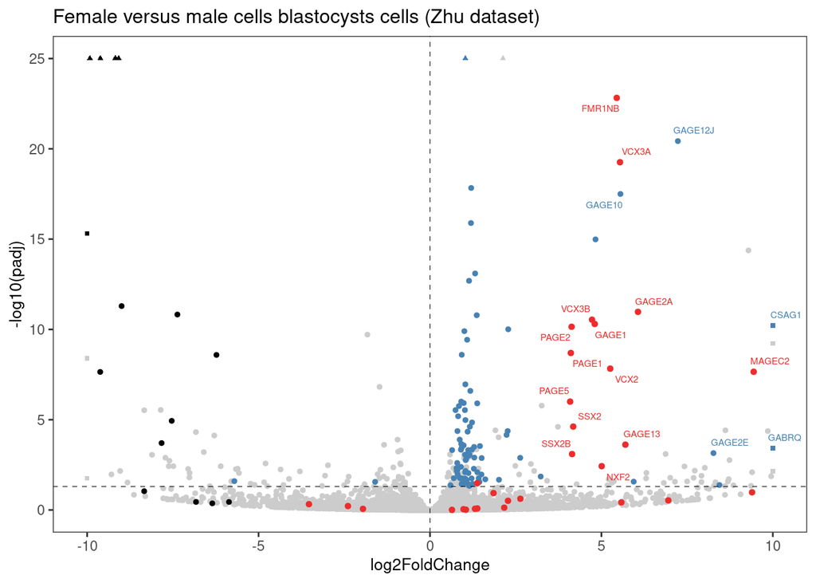

```r
fig
```

- Genes with a padjusted value < 10^{-25} are represented as triangles
- Genes with an absolute log2FC > 10 are represented as squares
- Red dots = X-linked MethDep genes
- Blue dots = X-linked genes not CG genes
- Black dots = Y-linked genes
- Gray dots = other genes